# Лингвистический анализ коннотации игрового сленга

Корнилова Елизавета

## Installs

```r
library(tidyverse)
```

```r
library(ggplot2)
library(plotly)
library(kableExtra)
library(factoextra)
library(vegan)
library(FactoMineR)
library(dplyr)
library(lmtest)
library(glmnet)
library(text2vec)
library(caret)
library(Matrix)
library(stringr)
library(vcd)
library(ggmosaic)
```

## Введение

**Цель проекта** - разработать модель классификации коннотации игрового сленга.

Датасет содержит термины игрового сленга из различных видеоигр и их классификацию по словообразовательным моделям. Проект продолжает и расширяет бакалаврскую работу, фокусируясь на определении оннотации сленговых слов и её зависимости от контекста, жанра игры, словообразовательной модели.

**Гипотезы:**

H₀: Коннотация слова не зависит от части речи. H₁: Коннотация слова зависит от части речи.

H₀: Коннотация слова не зависит от контекста. H₁: Коннотация слова зависит от контекста.

H₀: Коннотация слова не зависит от жанра игры. H₁: Коннотация слова зависит от жанра игры.

H₀: Коннотация слова не зависит от модели словообразования. H₁: Коннотация слова зависит от модели словообразования.

H₀: Коннотация слова не зависит от длины слова. H₁: Коннотация слова зависит от длины слова

**Переменные:**

- slang word: Сленговое слово или выражение
- word formation model: Модель словообразования
- context: Контекст использования термина
- part of speech: Часть речи
- Genre of game Where it appears: Жанр игры, где встречается термин
- Connotation: Коннотация (нейтральная, положительная, отрицательная)
- Sentence: Пример предложения со сленговым словом

**Целевая переменная** — Connotation (коннотация), которая принимает следующие значения: neutral, positive, negative, ambivalent, irony/sarcasm.

## Предварительный анализ данных

```r
df <- read.csv("gaming_slang_2.csv", stringsAsFactors = FALSE)
```

Тип данных: все переменные хранятся как текстовые (chr), что может потребовать их преобразования в факторы для анализа. Пустых значений нет.

```r
str(df)
```

```
## 'data.frame':    209 obs. of  7 variables:
##  $ slang.word                    : chr  "To min-max" "Speedrun" "Faceroll" "Bug user" ...
##  $ word.formation.model          : chr  "Word composition" "Word composition" "Word composition" "Word composition" ...
##  $ context                       : chr  "Managing the characteristics of the game character" "Strategies and gameplay" "Game atmosphere and state of the player" "Evaluating other users" ...
##  $ part.of.speech                : chr  "verb" "noun" "noun" "noun" ...
##  $ Genre.of.game.Where.it.appears: chr  "General" "Action" "MOBA" "General" ...
##  $ Connotation                   : chr  "ambivalent" "ambivalent" "irony/sarcasm" "negative" ...
##  $ Sentence                      : chr  "I min-maxed my warrior's gear to sacrifice defense for maximum DPS." "She set a new world record with her 22-minute dungeon speedrun." "Yes leveling does take a long time, but part of the reason why it's so boring is because it's a faceroll. " "Report any …
```

```r
summary(df)
```

```
##   slang.word        word.formation.model   context          part.of.speech
##  Length:209         Length:209           Length:209         Length:209
##  Class :character   Class :character     Class :character   Class :character
##  Mode  :character   Mode  :character     Mode  :character   Mode  :character
##  Genre.of.game.Where.it.appears Connotation          Sentence
##  Length:209                     Length:209         Length:209
##  Class :character               Class :character   Class :character
##  Mode  :character               Mode  :character   Mode  :character
```

```r
sum(is.na(df))
```

```
## [1] 0
```

```r
# Преобразование переменных в факторы
df$word.formation.model <- as.factor(df$word.formation.model)
df$context <- as.factor(df$context)
df$part.of.speech <- as.factor(df$part.of.speech)
df$Genre.of.game.Where.it.appears <- as.factor(df$Genre.of.game.Where.it.appears)
df$Connotation <- as.factor(df$Connotation)
```

Проверка категориальных переменных выводит все уникальные значения для каждого категориального признака и помогает оценить разнообразие категорий.

```r
cat("Уникальные значения коннотации:", levels(df$Connotation), "\n")
```

```
## Уникальные значения коннотации: ambivalent irony/sarcasm negative neutral positive
```

```r
cat("Уникальные модели словообразования:", levels(df$word.formation.model), "\n")
```

```
## Уникальные модели словообразования: Abbreviations Acronyms Clipping Conversion Metaphors Metonymy Reduplication Spoonerisms Suffixation Word composition
```

```r
cat("Уникальный контекст:", levels(df$context), "\n")
```

```
## Уникальный контекст: Communication process Evaluating other users Expressions associated with victory and defeat Game atmosphere and state of the player Game mechanics Games and game genres In-game creatures In-game indicators In-game items, resources, and phenomena Managing the characteristics o…
```

```r
cat("Уникальные части речи:", levels(df$part.of.speech), "\n")
```

```
## Уникальные части речи: adjective adverb  noun verb
```

```r
cat("Уникальные жанры игр:", levels(df$Genre.of.game.Where.it.appears), "\n")
```

```
## Уникальные жанры игр: Action FPS General MMORPG MMORPGB MOBA RPG Strategy
```

Так как в датасете полностью отсутсвуют числовые переменные, была добавлена новая переменная word_length, потому что это потенциально важный признак в задачах автоматического распознавания коннотации.

```r
df$word_length <- nchar(df$slang.word)
```

## Описательная статистика

**Распределение коннотации**

```r
connotation_palette <- c(
  "negative" = "salmon",
  "neutral" = "gray",
  "positive" = "gold",
  "ambivalent" = "lightgreen",
  "irony/sarcasm" = "mediumorchid"
)
```

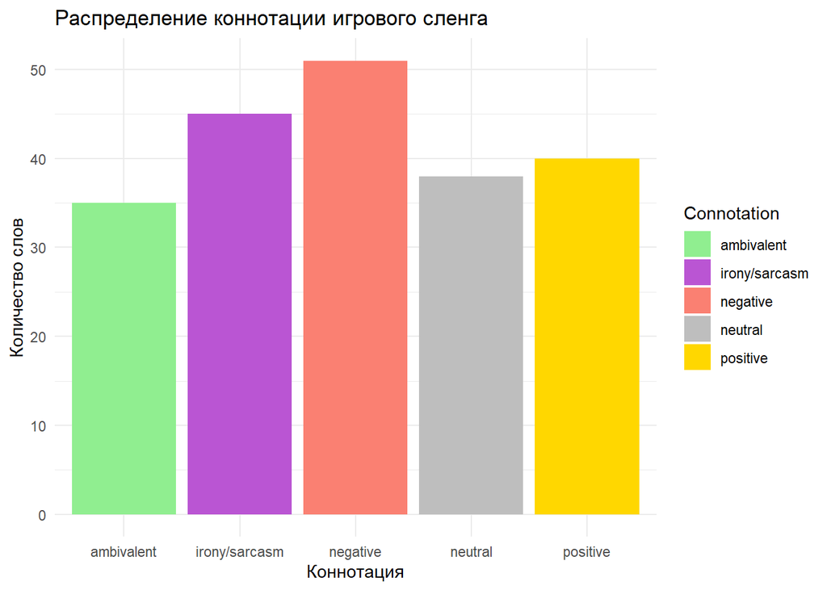

```r
ggplot(df, aes(x = Connotation, fill = Connotation)) +
  geom_bar() +
  scale_fill_manual(values = connotation_palette) +
  labs(title = "Распределение коннотации игрового сленга",
       x = "Коннотация", y = "Количество слов") +
  theme_minimal()
```

```r
table(df$Connotation)
```

```
##
##    ambivalent irony/sarcasm      negative       neutral      positive
##            35            45            51            38            40
```

**Вывод**: Игровой сленг выполняет преимущественно **оценочную** (а не описательную) функцию, с акцентом на негатив и иронию.

```r
# Создание функции для генерации таблиц распределения
create_connotation_table <- function(data, group_var) {
  data %>%
    group_by({{group_var}}, Connotation) %>%
    summarise(Count = n(), .groups = 'drop') %>%
    mutate(Percentage = round(Count / sum(Count) * 100, 1)) %>%
    pivot_wider(names_from = Connotation,
                values_from = c(Count, Percentage),
                names_sep = "_",
                values_fill = list(Count = 0, Percentage = 0))
}
```

**Распределение частей речи по коннотации**

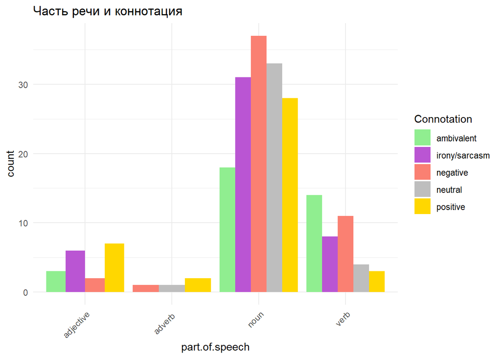

```r
ggplot(df, aes(x = part.of.speech, fill = Connotation)) +
  geom_bar(position = "dodge") +
  scale_fill_manual(values = connotation_palette) +
  theme_minimal() +
  theme(axis.text.x = element_text(angle = 45, hjust = 1)) +
  ggtitle("Часть речи и коннотация")
```

```r
part_of_speech_table <- df %>%
  separate_rows(part.of.speech, sep = ", ") %>%
  create_connotation_table(part.of.speech) %>%
  arrange(desc(Count_negative))

part_of_speech_table
```

```
## # A tibble: 4 × 11
##   part.of.speech Count_ambivalent `Count_irony/sarcasm` Count_negative
##   <chr>                     <int>                 <int>          <int>
## 1 "noun"                       18                    31             37
## 2 "verb"                       14                     8             11
## 3 "adjective"                   3                     6              2
## 4 "adverb "                     0                     0              1
## # ℹ 7 more variables: Count_positive <int>, Count_neutral <int>,
## #   Percentage_ambivalent <dbl>, `Percentage_irony/sarcasm` <dbl>,
## #   Percentage_negative <dbl>, Percentage_positive <dbl>,
## #   Percentage_neutral <dbl>
```

**Распределение жанров игр и коннотаци**

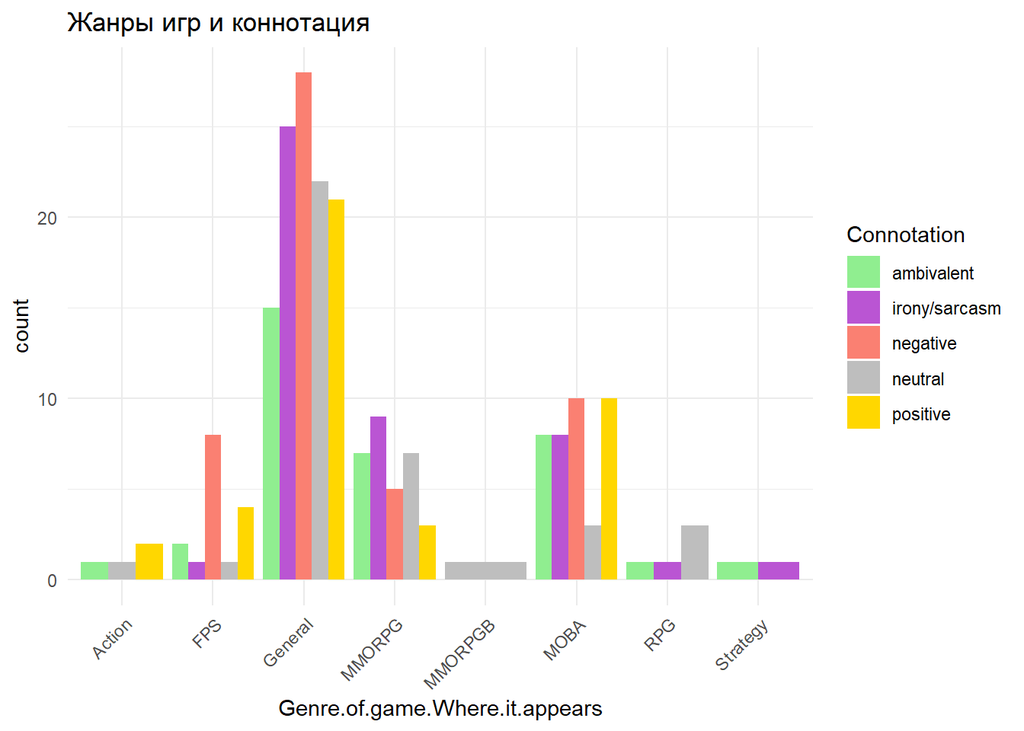

```r
ggplot(df, aes(x = Genre.of.game.Where.it.appears, fill = Connotation)) +
  geom_bar(position = "dodge") +
  scale_fill_manual(values = connotation_palette) +
  theme_minimal() +
  theme(axis.text.x = element_text(angle = 45, hjust = 1)) +
  ggtitle("Жанры игр и коннотация")
```

```r
genre_table <- create_connotation_table(df, Genre.of.game.Where.it.appears) %>%
  arrange(desc(Count_negative))
genre_table
```

```
## # A tibble: 8 × 11
##   Genre.of.game.Where.it.appears Count_ambivalent Count_neutral Count_positive
##   <fct>                                     <int>         <int>          <int>
## 1 General                                      15            22             21
## 2 MOBA                                          8             3             10
## 3 FPS                                           2             1              4
## 4 MMORPG                                        7             7              3
## 5 Action                                        1             1              2
## 6 MMORPGB                                       0             1              0
## 7 RPG                                           1             3              0
## 8 Strategy                                      1             0              0
## # ℹ 7 more variables: `Count_irony/sarcasm` <int>, Count_negative <int>,
## #   Percentage_ambivalent <dbl>, Percentage_neutral <dbl>,
## #   Percentage_positive <dbl>, `Percentage_irony/sarcasm` <dbl>,
## #   Percentage_negative <dbl>
```

**Ключевые наблюдения**:

**Распределение моделей словообразования и коннотации**

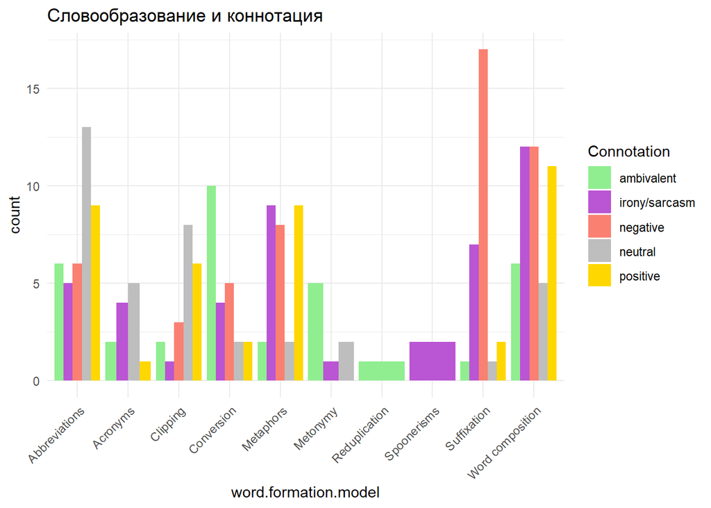

```r
ggplot(df, aes(x = word.formation.model, fill = Connotation)) +
  geom_bar(position = "dodge") +
  scale_fill_manual(values = connotation_palette) +
  theme_minimal() +
  theme(axis.text.x = element_text(angle = 45, hjust = 1)) +
  ggtitle("Словообразование и коннотация")
```

```r
formation_table <- create_connotation_table(df, word.formation.model) %>%
  arrange(desc(Count_negative))
formation_table
```

```
## # A tibble: 10 × 11
##    word.formation.model Count_ambivalent `Count_irony/sarcasm` Count_negative
##    <fct>                           <int>                 <int>          <int>
##  1 Suffixation                         1                     7             17
##  2 Word composition                    6                    12             12
##  3 Metaphors                           2                     9              8
##  4 Abbreviations                       6                     5              6
##  5 Conversion                         10                     4              5
##  6 Clipping                            2                     1              3
##  7 Acronyms                            2                     4              0
##  8 Metonymy                            5                     1              0
##  9 Reduplication                       1                     0              0
## 10 Spoonerisms                         0                     2              0
## # ℹ 7 more variables: Count_neutral <int>, Count_positive <int>,
## #   Percentage_ambivalent <dbl>, `Percentage_irony/sarcasm` <dbl>,
## #   Percentage_negative <dbl>, Percentage_neutral <dbl>,
## #   Percentage_positive <dbl>
```

**Распределение коннотации по контексту**

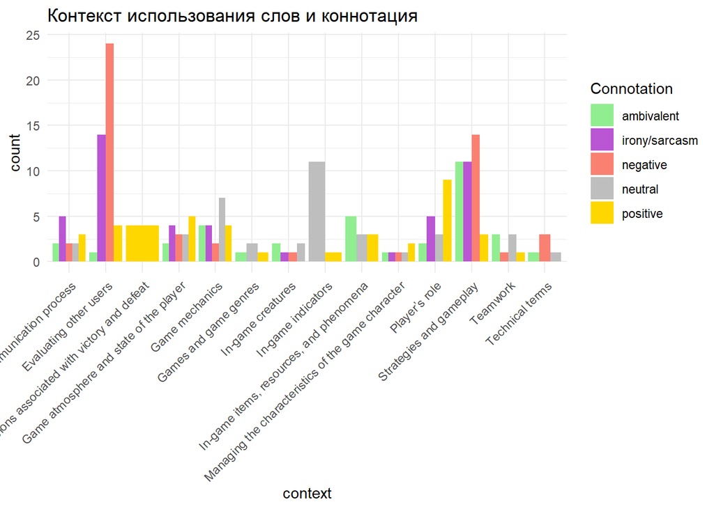

```r
ggplot(df, aes(x = context, fill = Connotation)) +
  geom_bar(position = "dodge") +
  scale_fill_manual(values = connotation_palette) +
  theme_minimal() +
  theme(axis.text.x = element_text(angle = 45, hjust = 1)) +
  ggtitle("Контекст использования слов и коннотация")
```

```r
context_table <- create_connotation_table(df, context) %>%
  arrange(desc(Count_negative))
context_table
```

```
## # A tibble: 14 × 11
##    context   Count_ambivalent `Count_irony/sarcasm` Count_negative Count_neutral
##    <fct>                <int>                 <int>          <int>         <int>
##  1 Evaluati…                1                    14             24             0
##  2 Strategi…               11                    11             14             0
##  3 Game atm…                2                     4              3             3
##  4 Technica…                1                     0              3             1
##  5 Communic…                2                     5              2             2
##  6 Game mec…                4                     4              2             7
##  7 In-game …                2                     1              1             2
##  8 Managing…                1                     1              1             1
##  9 Teamwork                 3                     0              1             3
## 10 Expressi…                0                     0              0             0
## 11 Games an…                1                     0              0             2
## 12 In-game …                0                     0              0            11
## 13 In-game …                5                     0              0             3
## 14 Player’s…                2                     5              0             3
## # ℹ 6 more variables: Count_positive <int>, Percentage_ambivalent <dbl>,
## #   `Percentage_irony/sarcasm` <dbl>, Percentage_negative <dbl>,
## #   Percentage_neutral <dbl>, Percentage_positive <dbl>
```

График и таблица ниже иллюстрируют, как длина сленговых слов распределена в зависимости от коннотации.

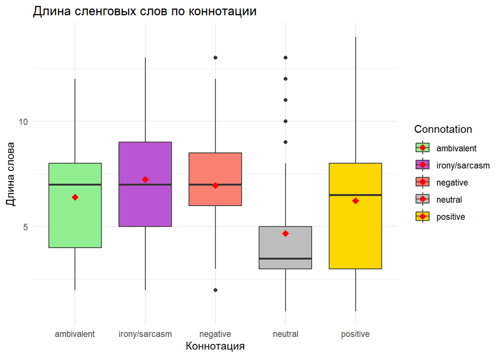

```r
ggplot(df, aes(x = Connotation, y = word_length, fill = Connotation)) +
  geom_boxplot() +
  scale_fill_manual(values = connotation_palette) +
  labs(title = "Длина сленговых слов по коннотации",
       x = "Коннотация", y = "Длина слова") +
  stat_summary(fun = mean, geom = "point", shape = 18, size = 3, color = "red") +
  theme_minimal()
```

```r
df %>%
  mutate(word_length = nchar(slang.word)) %>%
  group_by(Connotation) %>%
  summarise(mean_length = mean(word_length))
```

```
## # A tibble: 5 × 2
##   Connotation   mean_length
##   <fct>               <dbl>
## 1 ambivalent           6.4
## 2 irony/sarcasm        7.24
## 3 negative             6.96
## 4 neutral              4.68
## 5 positive             6.22
```

```r
# Основные статистики по длине слов
summary(df$word_length)
```

```
##    Min. 1st Qu.  Median    Mean 3rd Qu.    Max.
##   1.000   4.000   6.000   6.373   8.000  14.000
```

## Фреквентистская статистика

Перед проведение статистических тестов нужно проверить данные на нормальность.

```r
shapiro.test(df$word_length)
```

```
##
##  Shapiro-Wilk normality test
##
## data:  df$word_length
## W = 0.95702, p-value = 6.122e-06
```

```r
shapiro.test(df$word_length[df$Connotation == "positive"])
```

```
##
##  Shapiro-Wilk normality test
##
## data:  df$word_length[df$Connotation == "positive"]
## W = 0.92167, p-value = 0.008695
```

```r
shapiro.test(df$word_length[df$Connotation == "negative"])
```

```
##
##  Shapiro-Wilk normality test
##
## data:  df$word_length[df$Connotation == "negative"]
## W = 0.96489, p-value = 0.1348
```

```r
shapiro.test(df$word_length[df$Connotation == "irony/sarcasm"])
```

```
##
##  Shapiro-Wilk normality test
##
## data:  df$word_length[df$Connotation == "irony/sarcasm"]
## W = 0.9682, p-value = 0.2488
```

```r
shapiro.test(df$word_length[df$Connotation == "ambivalent"])
```

```
##
##  Shapiro-Wilk normality test
##
## data:  df$word_length[df$Connotation == "ambivalent"]
## W = 0.94786, p-value = 0.09743
```

```r
shapiro.test(df$word_length[df$Connotation == "neutral"])
```

```
##
##  Shapiro-Wilk normality test
##
## data:  df$word_length[df$Connotation == "neutral"]
## W = 0.81042, p-value = 1.716e-05
```

**Результаты проверки нормальности:**

1. Распределение длины слов не является нормальным, потому что p-value = 6.1e-06 < 0.05.
2. Распределены **нормально**: слова негативной коннотации (p-value = 0.1348 > 0.05) слова иронично-саркастичной коннотации (p-value = 0.2488 > 0.05) слова амбивалентной коннотации (p-value = 0.09743 > 0.05)
3. Распределены **ненормально**: слова позитивной коннотации (p-value = 0.0087 < 0.05) слова нейтральной коннотации (p-value = 1.716e-05 < 0.05)

Можно провести t-test между negative и irony/sarcasm или negative и ambivalent коннотацией, так как они распределены нормально.

```r
t.test(word_length ~ Connotation, data = df %>% filter(Connotation %in% c("negative", "irony/sarcasm")))
```

```
##
##  Welch Two Sample t-test
##
## data:  word_length by Connotation
## t = 0.48819, df = 88.215, p-value = 0.6266
## alternative hypothesis: true difference in means between group irony/sarcasm and group negative is not equal to 0
## 95 percent confidence interval:
##  -0.8709948  1.4383150
## sample estimates:
## mean in group irony/sarcasm      mean in group negative
##                    7.244444                    6.960784
```

```r
t.test(word_length ~ Connotation, data = df %>% filter(Connotation %in% c("negative", "ambivalent")))
```

```
##
##  Welch Two Sample t-test
##
## data:  word_length by Connotation
## t = -0.94533, df = 71.263, p-value = 0.3477
## alternative hypothesis: true difference in means between group ambivalent and group negative is not equal to 0
## 95 percent confidence interval:
##  -1.7435425  0.6219739
## sample estimates:
## mean in group ambivalent   mean in group negative
##                 6.400000                 6.960784
```

```r
t.test(word_length ~ Connotation, data = df %>% filter(Connotation %in% c("irony/sarcasm", "ambivalent")))
```

```
##
##  Welch Two Sample t-test
##
## data:  word_length by Connotation
## t = -1.3083, df = 75.96, p-value = 0.1947
## alternative hypothesis: true difference in means between group ambivalent and group irony/sarcasm is not equal to 0
## 95 percent confidence interval:
##  -2.1300170  0.4411281
## sample estimates:
##    mean in group ambivalent mean in group irony/sarcasm
##                    6.400000                    7.244444
```

**Интерпретация результатов t-теста:**

1. Высокое p-value (0.6266, 0.348, 0.195) говорит о том, что **нет статистически значимого различия** между средними длинами слов в группах “irony/sarcasm” и “negative”, “negative” и “ambivalent”, “irony/sarcasm” и “ambivalent”. 2.Доверительный интервал у всех групп 95% и включает 0, что также подтверждает отсутствие значимого различия.
2. Разница в средних небольшая, но показывает, что слова с ироничной-саркастической коннотацией длиннее слов с негативной на 0.28 и длинее слов с абивалентной на 0,8, а слова с негативной коннотацией длиннее слов с амбивалентной на 0.56.

Согласно результатам Welch t-теста, гипотеза о равенстве средних длины слов в группах “irony/sarcasm” и “negative” не отвергается. Это означает, что ироничные/саркастичные, негативные и амбивалентные термины не отличаются по длине.

Для проверки других видов коннотации будет использован тест Манна-Уитни (U-тест), так как он не требует нормальности распределения, в отличие от t-теста.

```r
connotations <- unique(df$Connotation)
pairs <- combn(connotations, 2, simplify = FALSE)

for (pair in pairs) {
  group1 <- pair[1]
  group2 <- pair[2]

  cat("\nТест Манна-Уитни для:", group1, "vs", group2, "\n")
  result <- wilcox.test(
    word_length ~ Connotation,
    data = df %>% filter(Connotation %in% c(group1, group2))
  )
  print(result)
}
```

```
##
## Тест Манна-Уитни для: 1 vs 2
```

```
##
##  Wilcoxon rank sum test with continuity correction
##
## data:  word_length by Connotation
## W = 654.5, p-value = 0.1961
## alternative hypothesis: true location shift is not equal to 0
##
##
## Тест Манна-Уитни для: 1 vs 3
##
##  Wilcoxon rank sum test with continuity correction
##
## data:  word_length by Connotation
## W = 791, p-value = 0.3702
## alternative hypothesis: true location shift is not equal to 0
##
##
## Тест Манна-Уитни для: 1 vs 5
```

```
##
##  Wilcoxon rank sum test with continuity correction
##
## data:  word_length by Connotation
## W = 743.5, p-value = 0.6448
## alternative hypothesis: true location shift is not equal to 0
##
##
## Тест Манна-Уитни для: 1 vs 4
```

```
##
##  Wilcoxon rank sum test with continuity correction
##
## data:  word_length by Connotation
## W = 919.5, p-value = 0.004541
## alternative hypothesis: true location shift is not equal to 0
##
##
## Тест Манна-Уитни для: 2 vs 3
##
##  Wilcoxon rank sum test with continuity correction
##
## data:  word_length by Connotation
## W = 1224, p-value = 0.5741
## alternative hypothesis: true location shift is not equal to 0
##
##
## Тест Манна-Уитни для: 2 vs 5
```

```
##
##  Wilcoxon rank sum test with continuity correction
##
## data:  word_length by Connotation
## W = 1075.5, p-value = 0.1215
## alternative hypothesis: true location shift is not equal to 0
##
##
## Тест Манна-Уитни для: 2 vs 4
```

```
##
##  Wilcoxon rank sum test with continuity correction
##
## data:  word_length by Connotation
## W = 1262.5, p-value = 0.0001784
## alternative hypothesis: true location shift is not equal to 0
##
##
## Тест Манна-Уитни для: 3 vs 5
##
##  Wilcoxon rank sum test with continuity correction
##
## data:  word_length by Connotation
## W = 1180, p-value = 0.1991
## alternative hypothesis: true location shift is not equal to 0
##
##
## Тест Манна-Уитни для: 3 vs 4
##
##  Wilcoxon rank sum test with continuity correction
##
## data:  word_length by Connotation
## W = 1440.5, p-value = 8.297e-05
## alternative hypothesis: true location shift is not equal to 0
##
##
## Тест Манна-Уитни для: 5 vs 4
```

```
##
##  Wilcoxon rank sum test with continuity correction
##
## data:  word_length by Connotation
## W = 562.5, p-value = 0.04567
## alternative hypothesis: true location shift is not equal to 0
```

**Интерпретация результатов тестов Манна-Уитн:**

Для большинства пар p-value больше 0.05, то есть различия статистически незначимы. Однако были обнаружены статистически значимые различия (p < 0.05):

1. Слова в нейтральной группе и амбивалентной имеют значимо разную длину (0.0045 < 0.05).
2. Значимы различия и в группе ироничные VS нейтральные (0.00018 < 0.05).
3. Отрицательные слова имеют статистически иную длину, чем нейтральные (0.0000829 < 0.05).
4. Различия между позитивными и нейтральными словами также значимы (0.0457 < 0.05).

Самый интересный вывод — нейтральная коннотация выделяется по длине слов. Это может означать, что нейтральные термины короче/длиннее по сравнению с стальными. Остальные эмоциональные категории — положительные, отрицательные, ироничные и амбивалентные — не сильно различаются между собой по длине слов.

Чтобы точно определить, короче или длиннее нейтральные слова по сравнению с другими типами коннотации, проводится сравнение медиан.

```r
df %>%
  group_by(Connotation) %>%
  summarise(
    Median = median(word_length),
    Mean = mean(word_length),
    SD = sd(word_length)
  ) %>%
  arrange(Median)
```

```
## # A tibble: 5 × 4
##   Connotation   Median  Mean    SD
##   <fct>          <dbl> <dbl> <dbl>
## 1 neutral          3.5  4.68  3.01
## 2 positive         6.5  6.22  3.50
## 3 ambivalent       7    6.4   2.75
## 4 irony/sarcasm    7    7.24  3.01
## 5 negative         7    6.96  2.64
```

**Ключевые закономерности:**

1. Нейтральные термины существенно короче всех остальных.
2. Позитивные термины занимают промежуточное положение.
3. Негативные, ироничные и амбивалентные термины самые длинные.

Подтверждается ранее полученными тестами:

Все сравнения нейтральных слов с другими типами коннотации были статистически значимыми (p < 0.05). Различия между негативными, ироничными и амбивалентными терминами незначимы.

Для проверки зависимости между категориальными переменными, проводится тест хи-квадрат, так как данных достаточно много и тест Фишера будет неэффектиным.

```r
# связь коннотации и жанра
chisq.test(table(df$Connotation,
                df$Genre.of.game.Where.it.appears))
```

```
##
##  Pearson's Chi-squared test
##
## data:  table(df$Connotation, df$Genre.of.game.Where.it.appears)
## X-squared = 35.294, df = 28, p-value = 0.1615
```

```r
# связь коннотации и контекста
chisq.test(table(df$context, df$Connotation))
```

```
##
##  Pearson's Chi-squared test
##
## data:  table(df$context, df$Connotation)
## X-squared = 163.6, df = 52, p-value = 1.814e-13
```

```r
# связь коннотации и модели словообразования
chisq.test(table(df$Connotation, df$word.formation.model))
```

```
##
##  Pearson's Chi-squared test
##
## data:  table(df$Connotation, df$word.formation.model)
## X-squared = 98.35, df = 36, p-value = 1.071e-07
```

```r
# связь коннотации и части речи
chisq.test(table(df$Connotation, df$part.of.speech))
```

```
##
##  Pearson's Chi-squared test
##
## data:  table(df$Connotation, df$part.of.speech)
## X-squared = 28.797, df = 12, p-value = 0.004222
```

**Интерпретация результатов теста хи-квадрат:**

1. **Коннотация и жанр игры** p > 0.05, значит, нет статистически значимой связи, жанр игры не влияет на коннотацию слова.
2. **Коннотация и контекст** p < 0.001, значит, очень сильная статистическая связь, контекст использования игрового сленга существенно влияет на коннотацию.
3. **Коннотация и словообразовательная модель** p < 0.001, значит, существенная зависимость, модель словообразования влияет на коннотацию.
4. **Коннотация и часть речи** p = 0.004222 < 0.05, значит, мы отвергаем H0, есть статистически значимая связь, коннотация слова зависит от части речи.

## Корреляционный анализ

В дополнение к хи-квадрат тесту используется Cramér’s V, показать силу зависимости переменных Connotation и context.

```r
tbl <- table(df$Connotation, df$context)
assocstats(tbl)
```

```
##                     X^2 df   P(> X^2)
## Likelihood Ratio 172.82 52 6.9944e-15
## Pearson          163.60 52 1.8141e-13
##
## Phi-Coefficient   : NA
## Contingency Coeff.: 0.663
## Cramer's V        : 0.442
```

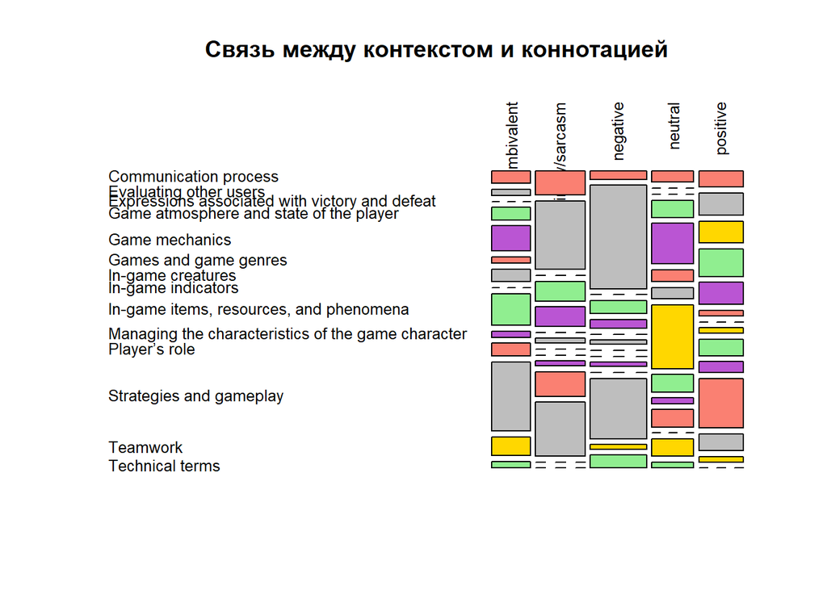

```r
mosaicplot(tbl,
           main = "Связь между контекстом и коннотацией",
           color = connotation_palette,
           shade = FALSE,
           las = 2,
           cex.axis = 0.8)
```

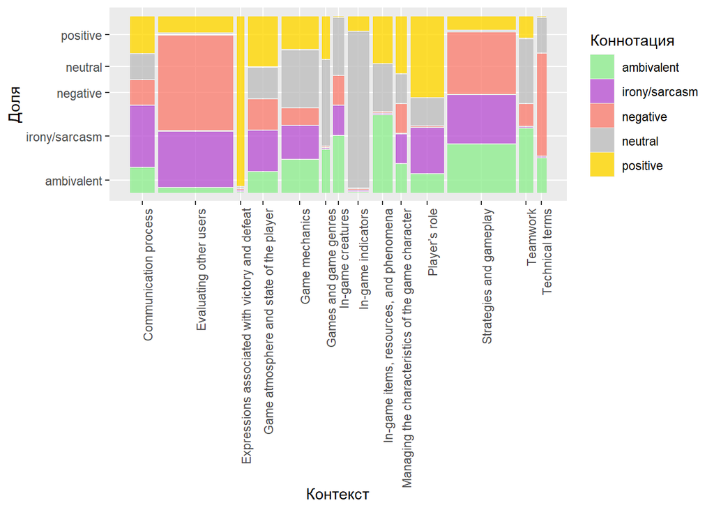

```r
ggplot(data = df) +
  geom_mosaic(aes(weight = 1, x = product(context), fill = Connotation)) +
  labs(x = "Контекст", y = "Доля", fill = "Коннотация") +
  theme(axis.text.x = element_text(angle = 90, hjust = 1))+
  scale_fill_manual(values = connotation_palette)
```

**Вывод:**

Распределения коннотаций заметно различаются между контекстами. Например:

- **“Evaluating other users”** — явно преобладает ирония и негатив.
- **“Victory / Player’s role”** — заметно больше позитивных слов.
- **“Game mechanics” и “In-game indicators”** — много нейтральных слов.

Результат Cramér’s V составил V = 0.442, что соответствует умеренной статистически значимой связи между контекстом и эмоциональной окраской сленговых слов. Это подтверждает, что контекст влияет на коннотацию слов.

## Методы сокращения размерности

Чтобы исследовать структуру категориальных признаков (жанр, контекст, часть речи, модель словообразования), был проведён множественный корреспондентный анализ (MCA). Результирующая проекция позволила визуализировать взаиморасположение категорий и выявить близость между признаками.

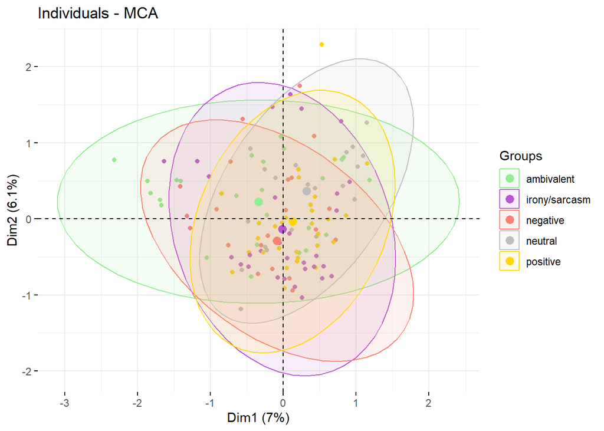

```r
gaming_slang_mca <- df %>%
  select(part.of.speech, context, Genre.of.game.Where.it.appears,
         word.formation.model) %>%
  mutate(across(everything(), as.factor))

mca_result <- MCA(gaming_slang_mca, ncp = 5, graph = FALSE)

fviz_mca_ind(mca_result,
             label = "none",
             habillage = df$Connotation,
             addEllipses = TRUE,
             repel = TRUE,
             palette = connotation_palette,
             ggtheme = theme_minimal())
```

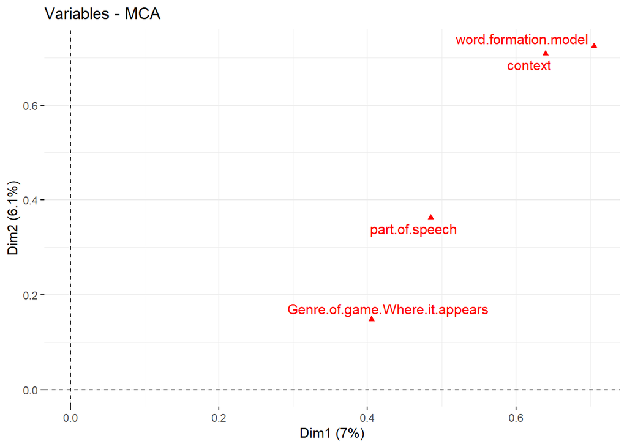

```r
fviz_mca_var(mca_result, choice = "mca.cor", repel = TRUE)
```

**Интерпретация анализа соответствий:**

График Variables-MCA отображает вклад переменных в мультикорреспондентный анализ (MCA). Он показывает, какие переменные сильнее всего связаны с главными компонентами (Dim1 и Dim2).

Для последующего анализа стоит акцентировать внимание на word.formation.model и context.

## Регрессионный анализ

В рамках данного проекта была разработана модель для предсказания коннотации игрового сленга.

**Цель модели:** разработать классификатор, способный автоматически определять коннотацию игрового сленга на основе текстовых признаков, включая контекст использования, жанр игры, часть речи и модель словообразования.

**Модель должна помочь:** автоматически анализировать тональность игровых терминов, улучшить модерацию чатов в онлайн-играх, исследовать закономерности использования сленга.

**Задачи модели:**

1. Предобработка данных: текстовая очистка, объединение признаков, обработка пропусков.
2. Балансировка данных: Oversampling и использование upSample() для устранения дисбаланса классов.
3. Векторизация текста (TF-IDF): токенизация, разбиение текста на слова и биграммы, построение словаря, отбор частотных терминов, преобразование в матрицу.
4. Обучение модели: логистическая регрессия (многоклассовая классификация) с регуляризацией (Elastic Net).
5. Оценка качества.

```r
# 1. Предобработка данных

# Очистка текста
clean_text <- function(text) {
  text %>%
    tolower() %>%
    stringi::stri_trans_general("Latin-ASCII") %>%
    str_replace_all("[^a-z0-9!? ]", " ") %>%
    str_squish()
}

# Объединение признаков
df$combined_text <- df %>%
  mutate(
    combined_text = paste(
      clean_text(Sentence),
      clean_text(part.of.speech),
      clean_text(Genre.of.game.Where.it.appears),
      clean_text(context),
      clean_text(word.formation.model)
    ) %>% str_squish()
  ) %>%
  pull(combined_text)

# NA
df_clean <- df %>% filter(!is.na(combined_text), !is.na(Connotation))

# 2. Балансировка данных
# Oversampling
set.seed(123)
upsampled_data <- upSample(
  x = df_clean["combined_text"],
  y = df_clean$Connotation,
  yname = "Connotation"
)

# Разделение данных
set.seed(123)
train_index <- createDataPartition(upsampled_data$Connotation, p = 0.8, list = FALSE)
train_data <- upsampled_data[train_index, ]
test_data <- upsampled_data[-train_index, ]

#3. Векторизация текста (TF-IDF)
tokens <- itoken(train_data$combined_text, tokenizer = word_tokenizer, progressbar = FALSE)
vocab <- create_vocabulary(tokens, ngram = c(1, 2)) %>%
  prune_vocabulary(term_count_min = 5)  # фильтрация редких

vectorizer <- vocab_vectorizer(vocab)

dtm_train <- create_dtm(tokens, vectorizer)
tfidf <- TfIdf$new()
dtm_train_tfidf <- fit_transform(dtm_train, tfidf)

# 4. Обучение модели
# Преобразование тестовой выборки
test_tokens <- itoken(test_data$combined_text,
                      tokenizer = word_tokenizer,
                      progressbar = FALSE)


dtm_test <- create_dtm(test_tokens, vectorizer)
dtm_test_tfidf <- transform(dtm_test, tfidf)

# Модель
model <- cv.glmnet(
  x = dtm_train_tfidf,
  y = train_data$Connotation,
  family = "multinomial",
  type.measure = "class",
  alpha = 0.5
)

# 5. Предсказания и оценка
preds <- predict(model, dtm_test_tfidf, s = "lambda.min", type = "class")
confusionMatrix(as.factor(preds), test_data$Connotation)
```

```
## Confusion Matrix and Statistics
##
##                Reference
## Prediction      ambivalent irony/sarcasm negative neutral positive
##   ambivalent             6             1        1       0        1
##   irony/sarcasm          1             8        3       2        3
##   negative               0             0        6       0        0
##   neutral                2             0        0       7        0
##   positive               1             1        0       1        6
##
## Overall Statistics
##
##                Accuracy : 0.66
##                  95% CI : (0.5123, 0.7879)
##     No Information Rate : 0.2
##     P-Value [Acc > NIR] : 2.173e-12
##
##                   Kappa : 0.575
##
##  Mcnemar's Test P-Value : NA
##
## Statistics by Class:
##
##                      Class: ambivalent Class: irony/sarcasm Class: negative
## Sensitivity                     0.6000               0.8000          0.6000
## Specificity                     0.9250               0.7750          1.0000
## Pos Pred Value                  0.6667               0.4706          1.0000
## Neg Pred Value                  0.9024               0.9394          0.9091
## Prevalence                      0.2000               0.2000          0.2000
## Detection Rate                  0.1200               0.1600          0.1200
## Detection Prevalence            0.1800               0.3400          0.1200
## Balanced Accuracy               0.7625               0.7875          0.8000
##                      Class: neutral Class: positive
## Sensitivity                  0.7000          0.6000
## Specificity                  0.9500          0.9250
## Pos Pred Value               0.7778          0.6667
## Neg Pred Value               0.9268          0.9024
## Prevalence                   0.2000          0.2000
## Detection Rate               0.1400          0.1200
## Detection Prevalence         0.1800          0.1800
## Balanced Accuracy            0.8250          0.7625
```

**Результаты:**

- Accuracy = 66% - модель показывает точность выше случайного угадывания
- Kappa = 0.575 — умеренное согласие модели с истинными метками.
- F1 ≈ 0.67

**Анализ метрик:**

1. **Для класса ambivalent:** модель находит 60% реальных ambivalent случаев.
2. **Для класса irony/sarcasm:** высокая Sensitivity, но слабая Precision: модель часто предсказывает иронию ошибочно.
3. **Для класса negative:** отличная Precision ((нет ложных срабатываний), но малая Sensitivity.
4. **Для класса neutral:** хороший баланс.
5. **Для класса positive:** слабее neutral, но лучше irony.

**Наблюдения:**

1. Классы “negative” и “neutral” имеют наименьшее количество ошибок
2. Классы “irony/sarcasm” и “positive” часто путаются между собой и с другими классами
3. Класс “negative” не имеет ложных срабатываний (все 6 предсказаний верны)
4. Модель хорошо отличает negative и neutral.

**Вывод:**

Модель демонстрирует хороший базовый уровень классификации, но требует доработки в области различения близких по смыслу классов (особенно irony/sarcasm и positive). Наибольшие проблемы связаны с многозначностью некоторых игровых терминов и дисбалансом в классах.

```r
# Функция для предсказания коннотации
predict_connotation <- function(sentence, model, vectorizer, tfidf) {
  token <- itoken(sentence,
                  preprocessor = tolower,
                  tokenizer = word_tokenizer,
                  progressbar = FALSE)

  dtm <- create_dtm(token, vectorizer)
  dtm_tfidf <- transform(dtm, tfidf)
  prediction <- predict(model, dtm_tfidf, s = "lambda.min", type = "class")
  return(as.character(prediction))
}
```

```r
# Предсказание коннотации предложения
predict_connotation("Press E to attack.", model, vectorizer, tfidf)
```

```
## [1] "neutral"
```

```r
predict_connotation("That player is a total feeder.", model, vectorizer, tfidf)
```

```
## [1] "negative"
```

```r
predict_connotation("You are a top banger.", model, vectorizer, tfidf)
```

```
## [1] "ambivalent"
```

```r
predict_connotation("Our team is a total clown fiesta.", model, vectorizer, tfidf)
```

```
## [1] "negative"
```

```r
predict_connotation("It is GG, guys.", model, vectorizer, tfidf)
```

```
## [1] "irony/sarcasm"
```

```r
predict_connotation("My new weapon imba", model, vectorizer, tfidf)
```

```
## [1] "positive"
```